# Bishop’s PRML, Chapter 6

May, 2015

This page contains source code relating to chapter 6 of Bishop’s *Pattern Recognition and Machine Learning* (2009)

This chapter is about Kernel Methods.

Kernels are functions in the form

$k(x,z) = \phi(x)^T \phi(z)$

where $\phi$ is a basis function (cf. chapter 3).

A *radial basis function* is a kernel which depends only on the distance between datapoints, ie, $k(x,z) = f(\|x-z\|)$.

An example:

$k(x,z) = \exp(-\gamma \|x-z\|^2)$

```r
make_gaussian_kernel <- function(gamma=1.0) {

  function(x,z) {
    exp(-gamma * norm(as.matrix(x-z),"F")^2 )
  }
}

gaussian_kernel <- make_gaussian_kernel(0.2)
gaussian_kernel(x=c(1,1), z=c(2,2))
```

```
## [1] 0.67032
```

## Constructing Kernels (section 6.2)

The hard way is to check if a given expression can be described as a product of basis.

Eg, $k(x,z) = (x^Tz)^2$ can be defined using basis $\phi(x) = (x_1^2, \sqrt{2}x_1x_2,x_2^2)^T$.

A simpler way is to build kernels from previous ones using rules like:

- $k(x,z) = f(x) k_1(x,z) f(z)$
- $k(x,z) = q(k_1(x,z))$, $q$ is a polynomial with nonnegative coefficients
- $k(x,z) = k_1(x,z) + k_2(x,z)$
- $k(x,z) = k_1(x,z) k_2(x,z)$
- $k(x,z) = \exp( k_1(x,z) )$
- $k(x,z) = x^T A z$, $A$ is a symmetric positive semidefinite matrix

where $k_1,k_2$ are already known kernels.

## Radial Basis Function Networks (section 6.3)

The RBF network originally was used for exact interpolation of the training dataset $X=(x_1,\ldots,x_N), Y=(y_1,\ldots,y_N)$.

The task was to find $W=(w_1,w_2,\ldots,w_N)$ such that

$y(x,W) = \sum_{i=1}^N w_i \times \exp(-\gamma \|x-x_i\|^2)$

gave a perfect match for all the initial datapoints $(x_i,y_i)$, ie, $y_i = y(x_i,W)$.

The design matrix $\Phi$ is (with a bias parameter $w_0$),

$\Phi = \left\lbrack \begin{matrix} 1 & exp(-\gamma \|x_1-x_1\|^2) & \cdots & exp(-\gamma \|x_1-x_N\|^2) \cr 1 & exp(-\gamma \|x_2-x_1\|^2) & \cdots & exp(-\gamma \|x_2-x_N\|^2) \cr \vdots & \vdots & \ddots & \vdots \cr 1 & exp(-\gamma \|x_N-x_1\|^2) & \cdots & exp(-\gamma \|x_N-x_N\|^2) \cr \end{matrix} \right\rbrack$

And so $W = (\Phi^T \Phi)^{-1} \Phi^T Y$ which is an exact interpolation of the dataset (it’s the pseudo inverse $(\Phi^T \Phi)^{-1} \Phi^T$ instead of the inverse $\Phi^{-1}$, because, by including the bias, $\Phi$ is no longer a square matrix).

However, if $N$ is large, the need to use all in-sample datapoints is exagerated and might overfit. A variant is to choose $K$ representatives ($K\lt\lt N$) that can do the interpolation. Choose the best $K$ centers among the possible $x_i \in X$ is NP-hard, so a possible option is to select $K$ centers using a clustering algorithm, namely a K-means clustering. Let’s name those centers $\mu_1, \ldots, \mu_K$. These $\mu_k$ define the set of *basis functions*.

Thus, the matrix form reduces the design matrix $\Phi$ from a $N \times (N+1)$ matrix to a smaller $N \times (K+1)$ matrix:

$\Phi = \left\lbrack \begin{matrix} 1 & exp(-\gamma \|x_1-\mu_1\|^2) & \cdots & exp(-\gamma \|x_1-\mu_K\|^2) \cr 1 & exp(-\gamma \|x_2-\mu_1\|^2) & \cdots & exp(-\gamma \|x_2-\mu_K\|^2) \cr \vdots & \vdots & \ddots & \vdots \cr 1 & exp(-\gamma \|x_N-\mu_1\|^2) & \cdots & exp(-\gamma \|x_N-\mu_K\|^2) \cr \end{matrix} \right\rbrack$

In R:

```r
# returns a rbf model given the:
# * observations X=(x1, ..., xN)
# * output value for each observation Y = (y1, ..., yN)
# * number of centers K
# * gamma value

rbf <- function(X, Y, K=12, gamma=1.0) {
  library(corpcor)   # include pseudoinverse()
  library(stats)     # include kmeans()

  N     <- dim(X)[1] # number of observations
  ncols <- dim(X)[2] # number of variables

  repeat {
    km <- kmeans(X, K)  # let's cluster K centers out of the dataset
    if (min(km$size)>0) # only accept if there are no empty clusters
      break
  }

  mus <- km$centers # the clusters points

  Phi <- matrix(rep(NA,(K+1)*N), ncol=K+1)
  for (lin in 1:N) {
    Phi[lin,1] <- 1    # bias column
    for (col in 1:K) {
      Phi[lin,col+1] <- exp(-gamma * norm(as.matrix(X[lin,]-mus[col,]),"F")^2)
    }
  }

  w <- pseudoinverse(t(Phi) %*% Phi) %*% t(Phi) %*% Y  # find RBF weights

  list(weights=w, centers=mus, gamma=gamma)  # return the rbf model
}
```

And also an implementation for the prediction function:

```r
rbf.predict <- function(model, X, classification=FALSE) {
  gamma   <- model$gamma
  centers <- model$centers
  w       <- model$weights
  N       <- dim(X)[1]    # number of observations

  pred <- rep(w[1],N)  # we need to init to a value, so let's start with bias

  for (j in 1:N) {
    # find prediction for point xj
    for (k in 1:length(centers[,1])) {
      # the weight for center[k] is given by w[k+1] (because w[1] is the bias)
      pred[j] <- pred[j] + w[k+1] * exp( -gamma * norm(as.matrix(X[j,]-centers[k,]),"F")^2 )
    }
  }

  if (classification) {
    pred <- unlist(lapply(pred, sign))
  }
  pred
}
```

Let’s see an example:

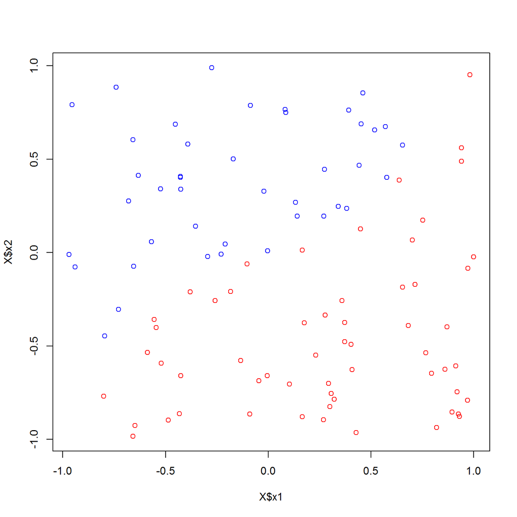

```r
target <- function(x1, x2) {
  2*(x2 - x1 + .25*sin(pi*x1) >= 0)-1
}

N <- 100
X <- data.frame(x1=runif(N, min=-1, max=1),
                x2=runif(N, min=-1, max=1))
Y <- target(X$x1, X$x2)
plot(X$x1, X$x2, col=Y+3)
```

Now let’s learn the dataset using the RBFs:

```r
rbf.model <- rbf(X, Y) # using default values for K and gamma
rbf.model
```

```
## $weights
##              [,1]
##  [1,]  -0.8916381
##  [2,]  -0.9345065
##  [3,]  -3.4113668
##  [4,]   8.8122640
##  [5,]  13.9391005
##  [6,]   2.6130550
##  [7,]  -4.9743924
##  [8,]   1.3381857
##  [9,]  -4.2822439
## [10,]  -2.6032711
## [11,]  -2.1925096
## [12,]   8.3972227
## [13,] -14.5458204
```

[output cut: 18 more lines]

And make a prediction over a new test set:

```r
N.test <- 200
X.out <- data.frame(x1=runif(N.test, min=-1, max=1),
                    x2=runif(N.test, min=-1, max=1))
Y.out <- target(X.out$x1, X.out$x2)

rbf.pred <- rbf.predict(rbf.model, X.out, classification=TRUE)
binary.error <- sum(rbf.pred != Y.out)/N.test
binary.error
```

```
## [1] 0.03
```

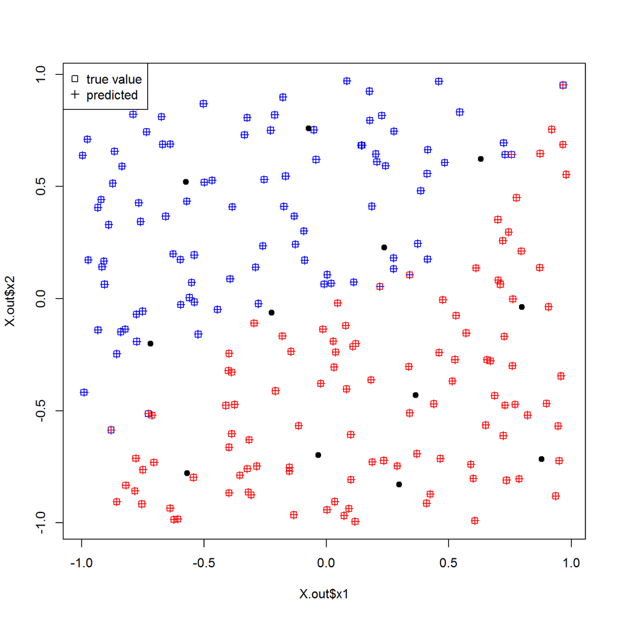

```r
plot(X.out$x1, X.out$x2, col=Y.out+3, pch=0)
points(X.out$x1, X.out$x2, col=rbf.pred+3, pch=3)
points(rbf.model$centers, col="black", pch=19) # draw the model centers
legend("topleft",c("true value","predicted"),pch=c(0,3),bg="white")
```

# Gaussian Processes (section 6.4)

Consider a model as a linear combination of some fixed basis $\phi$,

$y(x,W) = W^T \phi(x)$

Now let’s assume this prior distribution for W

$p(W) = \mathcal{N}(W|0,\alpha^{-1} I)$

where the hyparameter $\alpha$ defines the precision of the distribution.

This distribution over $W$ induces a distribution over $y(x,W)$. Notice however that $y(x,W)$ is now a *distribution over functions*, where each has its own set of values for $W$.

The next code is based on James Keirstead’s [post](http://www.jameskeirstead.ca/blog/gaussian-process-regression-with-r/).

```r
require(MASS)
```

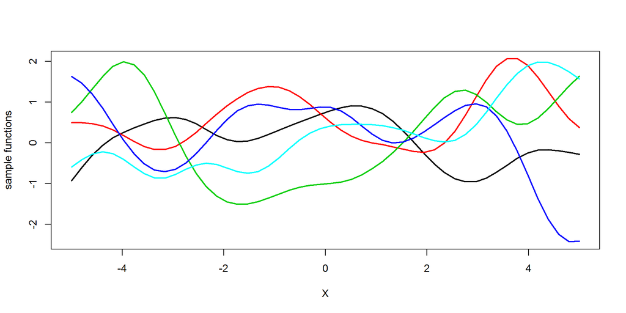

```r
# make the gaussian kernel
# gaussian_kernel <- make_gaussian_kernel(0.5)

# compute covariance matrix Sigma for the Gaussian process, ie,
# the distribution of functions (eqs. 6.53 & 6.54)
get_sigma <- function(X1, X2, kernel=make_gaussian_kernel(0.5)) {
  Sigma <- matrix(rep(0, length(X1)*length(X2)), nrow=length(X1))
  for (i in 1:nrow(Sigma))
    for (j in 1:ncol(Sigma))
       Sigma[i,j] <- kernel(X1[i], X2[j])
  Sigma
}

# The points at which we want to define the functions
X <- seq(-5,5,len=50)

# Calculate the covariance matrix
sigma <- get_sigma(X,X)
means <- rep(0, length(X))

# Generate sample functions from the Gaussian process
set.seed(101)
n_samples <- 5
y_sample  <- matrix(rep(0,length(X)*n_samples), ncol=n_samples)
for (i in 1:n_samples) {
  # each column represents a sample from a multivariate normal distribution
  # with zero mean and covariance sigma
  y_sample[,i] <- mvrnorm(1, means, sigma)
}

plot(X, y_sample[,1], type="n", ylim=c(min(y_sample), max(y_sample)), ylab="sample functions")
for(i in 1:n_samples)
  points(X, y_sample[,i], type="l", col=i, lwd=2)
```

## Gaussian Processes for Regression (section 6.4.2)

Usually, we wish these functions to evaluate to specific values at $y_i = y(x_i,W)$.

The next function receives $X$, which is a set of $X_i$ we wish to estimate, and output the estimations:

```r
# dataset:  two-column dataframe with col x for input, and col y for output
# kernel:   the kernel in use
# sd_noise: the standard deviation of the noise of the dataset samples
gp_samples <- function(X, dataset, kernel, n_samples, sd_noise=0, seed=121) {

  k.dd <- get_sigma(dataset$x, dataset$x, kernel)
  k.dx <- get_sigma(dataset$x, X,         kernel)
  k.xd <- get_sigma(X,         dataset$x, kernel)
  k.xx <- get_sigma(X,         X,         kernel)

  # These matrix calculations correspond to equation (2.19) in the
  # Rasmussen and Williams's book 'Gaussian Processes for ML'
  noise_part <- sd_noise^2 * diag(1, ncol(k.dd))

  d.star.bar <- k.xd %*% solve(k.dd + noise_part) %*% d$y
  cov.d.star <- k.xx - k.xd %*% solve(k.dd + noise_part) %*% k.dx

  # generate the samples
  set.seed(seed)
  y_sample <- matrix(rep(0,length(X)*n_samples), ncol=n_samples)
  for (i in 1:n_samples)
    y_sample[,i] <- mvrnorm(1, d.star.bar, cov.d.star)

  list(y_sample=y_sample, mean_est=d.star.bar)
}
```

Let’s try to fit some data:

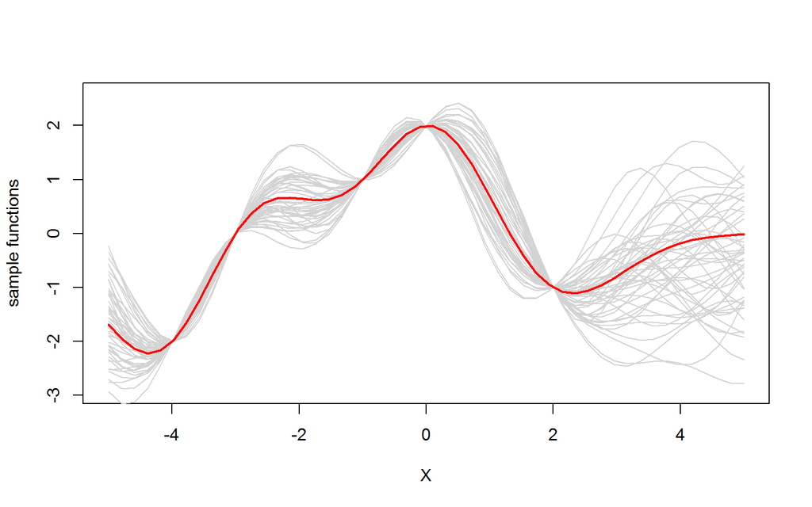

```r
d <- data.frame(x=c(-4,-3,-1,0 ,2),
                y=c(-2, 0 ,1,2,-1))
n_samples <- 50

result <- gp_samples(X, d, make_gaussian_kernel(0.5), n_samples)

plot(X, result$y_sample[,1], type="n", ylim=c(min(y_sample)-.5, max(y_sample)+.5), ylab="sample functions")
for(i in 1:n_samples)
  points(X, result$y_sample[,i], type="l", col="lightgrey")
points(X, result$mean_est, type="l", col="red", lwd=2)
```

We can estimate the output for a given value, say $2.3$.

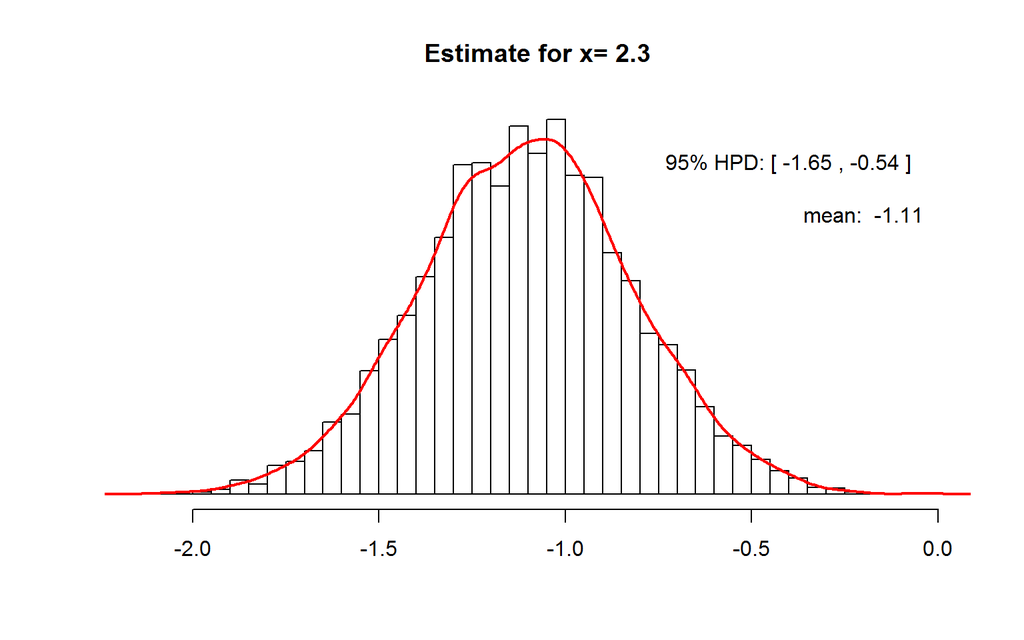

```r
value  <- 2.3
result <- gp_samples(value, d, make_gaussian_kernel(0.5), n_samples=5e3)

# i  <- 23 # eg: check the 23th value of X
ys <- result$y_sample[1,]
library(coda)
hpd <- HPDinterval(as.mcmc(ys), prob=0.95) # compute highest density interval

hist(ys, breaks=50, freq=FALSE, xlab="", main=paste("Estimate for x=",round(value,2)), yaxt='n', ylab="")
lines(density(ys),col="red",lwd=2)
text(-0.2,1.1,paste("mean: ",round(result$mean_est,2)))
text(-0.4,1.3,paste("95% HPD: [",round(hpd[1],2),",",round(hpd[2],2),"]"))
```

Also, we can assume that our data is noisy:

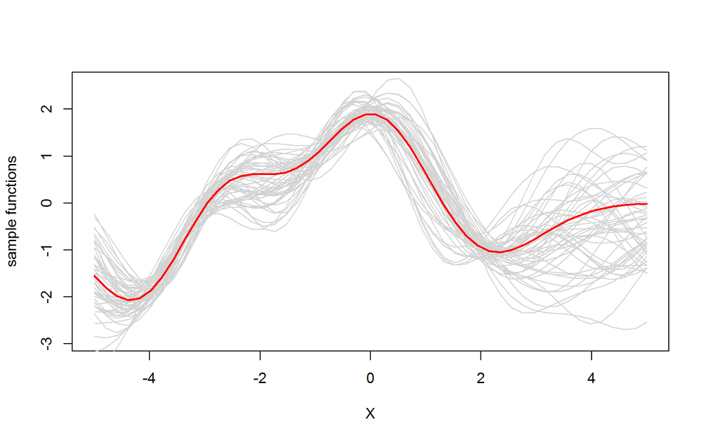

```r
result <- gp_samples(X, d, make_gaussian_kernel(0.5), n_samples, sd_noise=0.2)

plot(X, result$y_sample[,1], type="n", ylim=c(min(y_sample)-.5, max(y_sample)+.5), ylab="sample functions")
for(i in 1:n_samples)
  points(X, result$y_sample[,i], type="l", col="lightgrey")
points(X, result$mean_est, type="l", col="red", lwd=2)
```

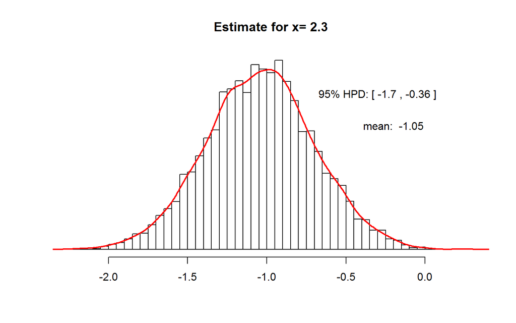

```r
# estimate for value
value <- 2.3
result <- gp_samples(value, d, make_gaussian_kernel(0.5), n_samples=5e3, sd_noise=0.2)

ys <- result$y_sample[1,]
hpd <- HPDinterval(as.mcmc(ys), prob=0.95) # compute highest density interval

hist(ys, breaks=50, freq=FALSE, xlab="", main=paste("Estimate for x=",round(value,2)), yaxt='n', ylab="")
lines(density(ys),col="red",lwd=2)
text(-0.2,0.8,paste("mean: ",round(result$mean_est,2)))
text(-0.3,1.0,paste("95% HPD: [",round(hpd[1],2),",",round(hpd[2],2),"]"))
```

Notice how the HPD is now larger.

This procedure can also be used with other kernels. The next one corresponds to the *Ornstein-Uhlenbeck process* useful to model Brownian motion.

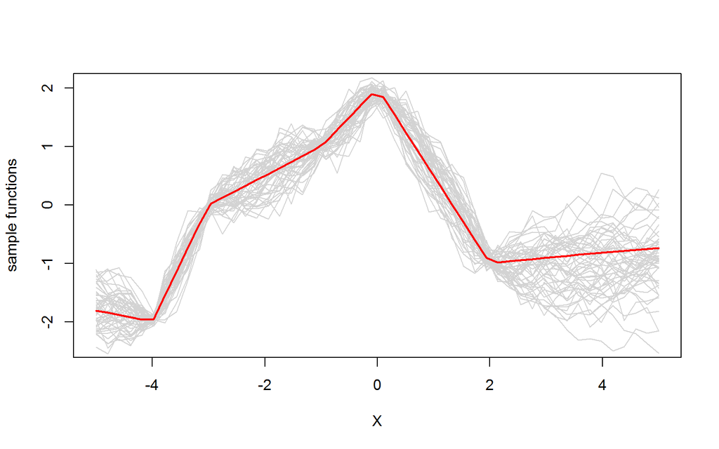

```r
exponential_kernel <- function(x,z) exp(-0.1*abs(x-z)) # parameter theta=0.1

result2 <- gp_samples(X, d, exponential_kernel, n_samples)

plot(X, result2$y_sample[,1], type="n", ylim=c(min(y_sample), max(y_sample)),
        ylab="sample functions")
for(i in 1:n_samples)
  points(X, result2$y_sample[,i], type="l", col="lightgrey")
points(X, result2$mean_est, type="l", col="red", lwd=2)
```

Check [library](http://artax.karlin.mff.cuni.cz/r-help/library/kernlab/html/gausspr.html) `gausspr` for regression and classification with Gaussian Processes. For more information, check http://www.gaussianprocess.org/.

There are several functions that convert a real value into the $[0,1]$ interval, for us to interpret it as a probability. Here we use the sigmoid:

```r
sigmoid <- function(x) 1/(1+exp(-x))
```

Now, given the training set and a new value to estimate, we compute a set of samples for that value and then convert them with the sigmoid. For results below $0.5$ we interpret the sample as class $y=-1$, otherwise as class $y=1$.

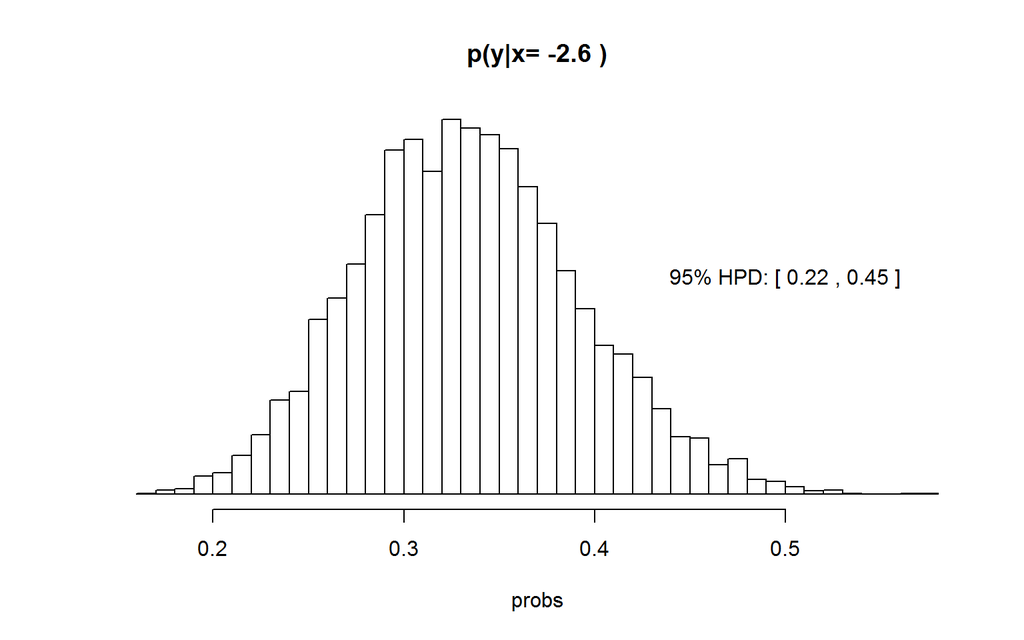

```r
d <- data.frame(x=c(-4,-3,-1, 0 ,2),
                y=c(-1,-1, 1, 1,-1))
value <- -2.6
result <- gp_samples(value, d, make_gaussian_kernel(0.5), n_samples=5e3)

probs <- sapply(result$y_sample[1,], sigmoid)
hpd   <- HPDinterval(as.mcmc(probs), prob=0.95)
hist(probs,breaks=50,prob=T, main=paste("p(y|x=",value,")"), yaxt='n', ylab="")
text(0.5,4.0,paste("95% HPD: [",round(hpd[1],2),",",round(hpd[2],2),"]"))
```

In this eg, we would classify the sample as class $-1$ within a $95\%$ credible interval.